# Scraping data from social media

Taken from code prepared by Pablo Barbera

### Scraping web data from Twitter

#### Authenticating

Follow these steps to create your token:

1. Go to apps.twitter.com and sign in.
2. Click on “Create New App”. You will need to have a phone number associated with your account in order to be able to create a token.
3. Fill name, description, and website (it can be anything, even http://www.google.com). Make sure you leave ‘Callback URL’ empty.
4. Agree to user conditions.
5. From the “Keys and Access Tokens” tab, copy consumer key and consumer secret and paste below

```r
# install.packages("ROAuth")
library(ROAuth)
requestURL <- "https://api.twitter.com/oauth/request_token"
accessURL <- "https://api.twitter.com/oauth/access_token"
authURL <- "https://api.twitter.com/oauth/authorize"
consumerKey <- "XXXXXXXXXXXX"
consumerSecret <- "YYYYYYYYYYYYYYYYYYY"

my_oauth <- OAuthFactory$new(consumerKey=consumerKey,
  consumerSecret=consumerSecret, requestURL=requestURL,
  accessURL=accessURL, authURL=authURL)
```

Run the below line and go to the URL that appears on screen. Then, type the PIN into the console (RStudio sometimes doesn’t show what you’re typing, but it’s there!)

```r
my_oauth$handshake(cainfo = system.file("CurlSSL", "cacert.pem", package = "RCurl"))
```

Now you can save oauth token for use in future sessions with smappR or streamR. Make sure you save it in a folder where this is the only file.

```r
save(my_oauth, file="~/git/data-science-workshop/scraping/credentials/twitter-token.Rdata")
```

#### Collecting data from Twitter’s Streaming API

Collecting tweets filtering by keyword:

```r
#install.packages("streamR")
library(streamR)
load("C:/Users/kevin/Dropbox/credentials/oauth_token27.RData")
filterStream(file.name="blizzard-tweets.json", track="blizzard",
    timeout=30, oauth=my_oauth)
```

```
## Capturing tweets...
```

```
## Connection to Twitter stream was closed after 30 seconds with up to 22 tweets downloaded.
```

Note the options: - `file.name` indicates the file in your disk where the tweets will be downloaded  
- `track` is the keyword(s) mentioned in the tweets we want to capture. - `timeout` is the number of seconds that the connection will remain open  
- `oauth` is the OAuth token we are using

Once it has finished, we can open it in R as a data frame with the `parseTweets` function

```r
tweets <- parseTweets("blizzard-tweets.json")
```

```
## 47 tweets have been parsed.
```

```r
str(tweets)
```

```
## 'data.frame':    47 obs. of  43 variables:
##  $ text                     : chr  "One time I was flipping it and forgot to take the double cup off and the whole mf blizzard fell cup included ht"| __truncated__ "RT @thebates20: I was at Dairy Queen earlier and when they flipped my blizzard it all fell out and I didnâ\200\"| __truncated__ "RT …
##  $ retweet_count            : num  0 2109 2107 2115 0 ...
##  $ favorite_count           : num  0 27241 27246 27358 0 ...
##  $ favorited                : logi  FALSE FALSE FALSE FALSE FALSE FALSE ...
##  $ truncated                : logi  FALSE FALSE FALSE FALSE FALSE FALSE ...
##  $ id_str                   : chr  "999380618613010432" "999380636405297152" "999380650720280576" "999380908099678209" ...
##  $ in_reply_to_screen_name  : chr  NA NA NA NA ...
##  $ source                   : chr  "<a href=\"http://twitter.com/download/iphone\" rel=\"nofollow\">Twitter for iPhone</a>" "<a href=\"http://twitter.com/download/iphone\" rel=\"nofollow\">Twitter for iPhone</a>" "<a href=\"http://twitter.com/download/iphone\" rel=\"nofollow\">Twitter for iPhone<…
##  $ retweeted                : logi  FALSE NA NA NA NA NA ...
##  $ created_at               : chr  "Wed May 23 20:04:41 +0000 2018" "Wed May 23 20:04:45 +0000 2018" "Wed May 23 20:04:49 +0000 2018" "Wed May 23 20:05:50 +0000 2018" ...
##  $ in_reply_to_status_id_str: int  NA NA NA NA NA NA NA NA NA NA ...
##  $ in_reply_to_user_id_str  : chr  NA NA NA NA ...
##  $ lang                     : chr  "en" "en" "en" "en" ...
##  $ listed_count             : num  3 2 0 8 49 1 3 541 5 15 ...
```

[output cut: 29 more lines]

```r
tweets[1,]
```

```
##                                                                                                                                   text
## 1 One time I was flipping it and forgot to take the double cup off and the whole mf blizzard fell cup included https://t.co/JEFjS2UmRx
##   retweet_count favorite_count favorited truncated             id_str
## 1             0              0     FALSE     FALSE 999380618613010432
##   in_reply_to_screen_name
## 1                    <NA>
##                                                                               source
## 1 <a href="http://twitter.com/download/iphone" rel="nofollow">Twitter for iPhone</a>
##   retweeted                     created_at in_reply_to_status_id_str
## 1     FALSE Wed May 23 20:04:41 +0000 2018                        NA
##   in_reply_to_user_id_str lang listed_count verified location user_id_str
## 1                    <NA>   en            3    FALSE     <NA>   461689762
##                      description geo_enabled
## 1 university of iowa | alpha chi        TRUE
##                  user_created_at statuses_count followers_count
## 1 Thu Jan 12 02:36:03 +0000 2012          35773            1502
##   favourites_count protected                user_url name
## 1            17490     FALSE http://vsco.co/beazzyyy    B
##                    time_zone user_lang utc_offset friends_count
## 1 Eastern Time (US & Canada)        en     -14400           748
##   screen_name country_code country place_type full_name place_name
## 1   B_Eazzyyy           NA      NA         NA        NA         NA
##   place_id place_lat place_lon lat lon
## 1       NA       NaN       NaN  NA  NA
##                                               expanded_url
## 1 https://twitter.com/thebates20/status/999034620720148483
##                       url
## 1 https://t.co/JEFjS2UmRx
```

And this is how we would capture tweets mentioning multiple keywords:

```r
filterStream(file.name="snow-tweets.json",
    track=c("blizzard", "snow", "winter storm", "snowfall"),
    tweets=50, oauth=my_oauth)
```

Finally, it’s also possible to collect a random sample of tweets. That’s what the “sampleStream” function does:

```r
sampleStream(file.name="tweets_random.json", timeout=30, oauth=my_oauth)
```

```
## Capturing tweets...
```

```
## Connection to Twitter stream was closed after 30 seconds with up to 1874 tweets downloaded.
```

Here I’m collecting 30 seconds of tweets. And once again, to open the tweets in R…

```r
tweets <- parseTweets("tweets_random.json")
```

```
## 3589 tweets have been parsed.
```

What is the most retweeted tweet?

```r
tweets[which.max(tweets$retweet_count),]
```

```
##                                                                              text
## 929 RT @kostka_chris: lemme bless yâ\200\231all with this video https://t.co/lwUIY3rwPj
##     retweet_count favorite_count favorited truncated             id_str
## 929        433291        1048143     FALSE     FALSE 999729383085555712
##     in_reply_to_screen_name
## 929                    <NA>
##                                                                                 source
## 929 <a href="http://twitter.com/download/iphone" rel="nofollow">Twitter for iPhone</a>
##     retweeted                     created_at in_reply_to_status_id_str
## 929     FALSE Thu May 24 19:10:33 +0000 2018                      <NA>
##     in_reply_to_user_id_str lang listed_count verified location
## 929                    <NA>   en            0    FALSE     <NA>
##     user_id_str description geo_enabled                user_created_at
## 929  1969955899        <NA>       FALSE Sat Oct 19 00:59:05 +0000 2013
##     statuses_count followers_count favourites_count protected user_url
## 929           9823             159             6914     FALSE     <NA>
##            name time_zone user_lang utc_offset friends_count screen_name
## 929 ali mahamed      <NA>     zh-cn         NA          2339  jumphorser
##     country_code country place_type full_name place_name place_id
## 929         <NA>    <NA>         NA      <NA>       <NA>     <NA>
##     place_lat place_lon lat lon expanded_url  url
## 929       NaN       NaN  NA  NA         <NA> <NA>
```

What are the most popular hashtags at the moment? We’ll use regular expressions to extract hashtags.

```r
library(stringr)
ht <- str_extract_all(tweets$text, "#(\\d|\\w)+")
ht <- unlist(ht)
head(sort(table(ht), decreasing = TRUE))
```

```
## ht
## #Ø #Ù #ì #ë #ã #à
## 64 22 15 14 13 12
```

How many tweets mention Justin Bieber?

```r
length(grep("bieber", tweets$text, ignore.case=TRUE))
```

```
## [1] 1
```

#### Collecting data from Twitter’s REST API

This is how you would extract information from user profiles:

```r
library(tweetscores)
reps <- c("RealBenCarson", "tedcruz", "CarlyFiorina", "GrahamBlog",
    "GovMikeHuckabee", "GovernorPataki", "RandPaul", "marcorubio",
    "RickSantorum", "bobbyjindal", "GovernorPerry", "realDonaldTrump",
    "JebBush", "GovChristie", "JohnKasich", "ScottWalker",
    "gov_gilmore")
dems <- c('HillaryClinton', 'SenSanders', "MartinOMalley",
    "LincolnChafee", "JimWebbUSA")
candidates <- c(reps, dems)

users <- getUsersBatch(screen_names=candidates,
                       oauth="C:/Users/kevin/Dropbox/credentials")
```

```
## 1--22 users left
```

```r
str(users)
```

```
## 'data.frame':    22 obs. of  9 variables:
##  $ id_str         : chr  "14845376" "113047940" "58379000" "3021632183" ...
##  $ screen_name    : chr  "GrahamBlog" "JebBush" "RickSantorum" "gov_gilmore" ...
##  $ name           : chr  "Lindsey Graham" "Jeb Bush" "Rick Santorum" "Jim Gilmore" ...
##  $ description    : chr  "Twitter feed for U.S. Senator Lindsey Graham of South Carolina." "43rd Governor of Florida. Connect on Facebook: https://t.co/e8DhvF8teu" "Grateful husband, blessed dad of 8. Working in waste-energy, cyber security & opiate addiction. Chair @Patriot_"| __truncated__ "Pat…
##  $ followers_count: int  114185 1472152 300391 5611 3680095 20968 370663 257075 966405 228948 ...
##  $ statuses_count : int  4242 4928 6298 2584 8251 3610 3516 3482 11019 13596 ...
##  $ friends_count  : int  2102 320 1366 2034 2411 504 28404 20184 10062 2130 ...
##  $ created_at     : chr  "Tue May 20 13:57:21 +0000 2008" "Wed Feb 10 14:45:07 +0000 2010" "Mon Jul 20 03:36:46 +0000 2009" "Fri Feb 06 15:50:24 +0000 2015" ...
##  $ location       : chr  "Washington, DC" "Miami, FL" "Pittsburgh & Virginia" "Richmond, VA" ...
```

Who is the candidate with the most followers?

```r
users[which.max(users$followers_count),]
```

```
##      id_str     screen_name            name
## 15 25073877 realDonaldTrump Donald J. Trump
##                                                               description
## 15 45th President of the United States of America🇺🇸
##    followers_count statuses_count friends_count
## 15        52210208          37624            46
##                        created_at       location
## 15 Wed Mar 18 13:46:38 +0000 2009 Washington, DC
```

Download up to 3,200 recent tweets from a Twitter account:

```r
getTimeline(filename="trump-tweets.json", screen_name="realDonaldTrump",
    n=1000, oauth="C:/Users/kevin/Dropbox/credentials")
```

```
## 200 tweets. Max id: 989948140814991360
```

```
## 893 hits left
```

```
## 400 tweets. Max id: 981248899166932994
```

```
## 892 hits left
```

```
## 600 tweets. Max id: 968702480753315840
```

```
## 891 hits left
```

```
## 800 tweets. Max id: 955056249925750784
```

```
## 890 hits left
```

```
## 1000 tweets. Max id: 946415026402988033
```

What are the most common hashtags?

```r
library(streamR)
library(stringr)
tweets <- parseTweets("trump-tweets.json")
```

```
## 2000 tweets have been parsed.
```

```r
ht <- str_extract_all(tweets$text, "#(\\d|\\w)+")
ht <- unlist(ht)
head(sort(table(ht), decreasing = TRUE))
```

```
## ht
##                  #MAGA                #TaxDay                 #WEF18
##                     28                      8                      6
##               #AMERICA                #MAGAðŸ #MakeAmericaGreatAgain
##                      4                      4                      4
```

Download friends and followers:

```r
followers <- getFollowers("kmmunger",
    oauth="C:/Users/kevin/Dropbox/credentials")
```

```
## C:/Users/kevin/Dropbox/credentials/oauth_token.Rdata
```

```
## 14 API calls left
```

```
## 932 followers. Next cursor: 0
```

```
## 13 API calls left
```

What are the most common words that my followers use to describe themselves on Twitter?

```r
library(quanteda)
# extract profile descriptions
users <- getUsersBatch(ids=followers,
    oauth="C:/Users/kevin/Dropbox/credentials")
```

```
## 1--932 users left
```

```
## 2--832 users left
```

```
## 3--732 users left
```

```
## 4--632 users left
```

```
## 5--532 users left
```

```
## 6--432 users left
```

```
## 7--332 users left
```

```
## 8--232 users left
```

```
## 9--132 users left
```

```
## 10--32 users left
```

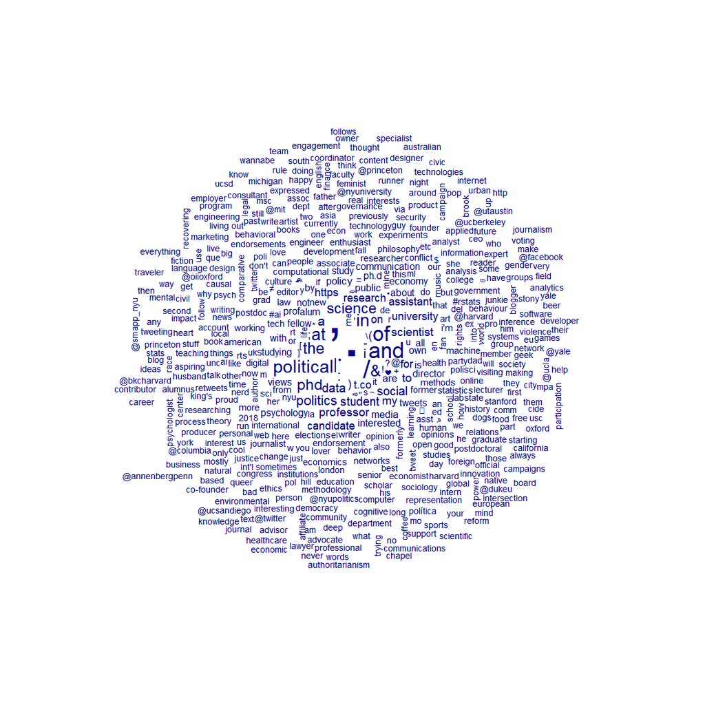

```r
# create table with frequency of word use
my_dfm <- dfm(users$description[users$description!=""])

# create wordcloud
par(mar=c(0,0,0,0))
textplot_wordcloud(my_dfm)
```